# GDSC Matrix: data overview and exploratory analysis

Michael Tran

2026-10-30

The GDSC Matrix screen measures pairwise drug responses across 755 cancer cell lines and 37 named treatments representing 46 source compound IDs. The PharmacoSet combines measured dose grids, observed and fitted synergy summaries, and molecular profiles. This walkthrough shows how to select compounds, inspect coverage, compare published and recomputed scores, and prioritize combinations descriptively. See the [source study](https://pmc.ncbi.nlm.nih.gov/articles/PMC11061612/) for acquisition and assay details.

## Getting started

Read the serialized PharmacoSet with PharmacoGx. Response records use identifiers from `sampleInfo()` and `treatmentInfo()`; join labels through these tables instead of assuming a display name is the stored key. Keep dose, plate and technical-context fields when selecting observations.

```r
library(PharmacoGx)
library(MultiAssayExperiment)
library(data.table)
pset <- readRDS("GDSC_MATRIX_PSet.rds")
samples <- sampleInfo(pset)
drugs <- treatmentInfo(pset)
response <- treatmentResponse(pset)
raw <- response[["raw"]]
profiles <- response[["profiles"]]
omics <- molecularProfilesSlot(pset)
```

## Contents and identifiers

The counts distinguish physical observations from fitted or aggregated profiles. Molecular coverage varies across assays; analyses should intersect sample IDs explicitly.

| dataset | samples | named_treatments | source_treatments | physical_observations |
| --- | --- | --- | --- | --- |
| GDSC Matrix | 755 | 37 | 46 | 3915245 |

| assay | rows |
| --- | --- |
| raw | 3915245 |
| synergy | 3915245 |
| monotherapy_profiles | 84055 |
| profiles | 84055 |

| sampleid | sample_name | tissueid | Cellosaurus.Accession |
| --- | --- | --- | --- |
| 1 | SW48 | Large Intestine | CVCL_1724 |
| 1000 | WM-115 | Skin | CVCL_0040 |
| 1001 | IST-MES1 | Lung | CVCL_1311 |
| 1002 | OCUB-M | Breast | CVCL_1621 |
| 1003 | SK-MM-2 | Haematopoietic and Lymphoid | CVCL_1699 |

| treatmentid | treatmentid_dataset | treatment_name | PubChem.CID |
| --- | --- | --- | --- |
| AZD6738 | 2435 | AZD6738 | NA |
| AZD1775 | 1735///2436 | AZD1775 | NA |
| AZD2811 | 2428 | AZD2811 | NA |
| AZD0156 | 1705///2429 | AZD0156 | NA |
| AZD7648 | 2430///2491 | AZD7648 | 135151360 |

### Select a treatment and join readable labels

Treatment IDs use readable source names. Identical names share one treatment metadata row; `treatmentid_dataset` retains all contributing source IDs. Response rows retain `treatment1id_source` and `treatment2id_source`, so measurements and fits remain distinct. This example selects a named treatment without pooling its source observations.

```r
selected_id <- raw$treatment1id[[1]]
example <- raw[treatment1id == selected_id,
  .(sampleid, treatment1id, treatment1id_source, treatment1dose, dose_unit, viability)][1:5]
example <- merge(example,
  as.data.table(samples)[, .(sampleid, sample_name)], by="sampleid", all.x=TRUE)
example <- merge(example,
  as.data.table(drugs)[, .(treatment1id=treatmentid, treatment_name)],
  by="treatment1id", all.x=TRUE)
knitr::kable(example)
```

| treatment1id | sampleid | treatment1id_source | treatment1dose | dose_unit | viability | sample_name | treatment_name |
| --- | --- | --- | --- | --- | --- | --- | --- |
| AZD0156 | 1 | 2429 | 0.0010005 | uM | 0.9281724 | SW48 | AZD0156 |
| AZD0156 | 1000 | 2429 | 0.0010005 | uM | 0.9289412 | WM-115 | AZD0156 |
| AZD0156 | 1001 | 2429 | 0.0010005 | uM | 1.0000000 | IST-MES1 | AZD0156 |
| AZD0156 | 1002 | 2429 | 0.0010005 | uM | 1.0000000 | OCUB-M | AZD0156 |
| AZD0156 | 1003 | 2429 | 0.0010005 | uM | 0.9544753 | SK-MM-2 | AZD0156 |

### Align a molecular assay with response samples

Use the experiment’s feature metadata to interpret its rows and its column metadata to interpret samples. Match by identifiers; row or column position is not a biological mapping.

```r
se <- experiments(molecularProfilesSlot(pset))[["rnaseq.tpm"]]
shared_samples <- intersect(samples$sampleid, colnames(se))
values <- SummarizedExperiment::assay(se)
knitr::kable(data.frame(assay="rnaseq.tpm", features=nrow(values),
  shared_response_samples=length(shared_samples)))
```

| assay | features | shared_response_samples |
| --- | --- | --- |
| rnaseq.tpm | 36998 | 752 |

```r
knitr::kable(values[seq_len(min(4,nrow(values))), head(shared_samples,4), drop=FALSE])
```

|  | 1 | 1000 | 1001 | 1002 |
| --- | --- | --- | --- | --- |
| ENSG00000000003 | 24.34 | 16.75 | 22.78 | 34.11 |
| ENSG00000000005 | 0.00 | 0.00 | 0.00 | 0.07 |
| ENSG00000000419 | 111.43 | 138.52 | 190.99 | 203.93 |
| ENSG00000000457 | 5.63 | 8.17 | 3.78 | 20.39 |

The earlier collaborator-curated GDSC objects use named treatments and a historical `rna` microarray assay. This object uses named treatments with preserved source-ID keys and the CMP 2022 `rnaseq.*` expression assays. It does not include a microarray assay. Grouping names does not pool measurements or make expression scales equivalent.

## Fitted concentration convention

Stored IC50 uses the relative half-effect convention (`reference="relative"`): it is not necessarily the concentration at 50% absolute viability. EC50 is the fitted midpoint. Read these values alongside the tested concentration range and curve asymptotes; extrapolated potency can be poorly identified.

## Annotation coverage

Unmatched identifiers remain usable source IDs. Empty AnnotationGx fields mean that mapping method was not run; they do not indicate a negative database result.

| entity | total | annotationdb_mapped |
| --- | --- | --- |
| samples | 755 | 700 |
| treatments | 37 | 25 |

annotationdb_cell_line_misses

| sampleid | sample_name | tissueid | COSMIC_ID | model_id | Cellosaurus.Accession | In.AnnotationDB | AnnotationGx.Mapped | AnnotationGx.Title |
| --- | --- | --- | --- | --- | --- | --- | --- | --- |
| 1006 | CS1 | Bone | 1290795 | SIDM00199 | NA | FALSE | NA | NA |
| 1032 | Mo-T | Haematopoietic and Lymphoid | 908149 | SIDM00623 | NA | FALSE | NA | NA |
| 1033 | NB10 | Peripheral Nervous System | 949171 | SIDM00259 | NA | FALSE | NA | NA |
| 114 | WM793B | Skin | 1299081 | SIDM00973 | NA | FALSE | NA | NA |
| 1161 | C3A | Liver | 910850 | SIDM01237 | NA | FALSE | NA | NA |
| 1173 | G-361 | Skin | 906865 | SIDM00857 | NA | FALSE | NA | NA |
| 1179 | SH-4 | Skin | 909713 | SIDM01079 | NA | FALSE | NA | NA |
| 1212 | HT-29 | Large Intestine | 905939 | SIDM00136 | NA | FALSE | NA | NA |
| 1270 | TT | Thyroid | 930299 | SIDM00484 | NA | FALSE | NA | NA |
| 1271 | RCM-1 | Large Intestine | 909263 | SIDM00359 | NA | FALSE | NA | NA |
| 1320 | BE2-M17 | Peripheral Nervous System | 753616 | SIDM01229 | NA | FALSE | NA | NA |
| 1387 | KS-1 | Central Nervous System | 907313 | SIDM00555 | NA | FALSE | NA | NA |
| 1398 | NOS-1 | Bone | 925345 | SIDM00242 | NA | FALSE | NA | NA |
| 1493 | TE-1 | Esophagus | 753621 | SIDM00369 | NA | FALSE | NA | NA |
| 1511 | A3-KAW | Haematopoietic and Lymphoid | 910935 | SIDM00495 | NA | FALSE | NA | NA |

annotationdb_compound_misses

| treatmentid | treatment_name | target | pathway | PubChem.CID | In.AnnotationDB | AnnotationGx.Mapped | AnnotationGx.Title |
| --- | --- | --- | --- | --- | --- | --- | --- |
| 2435 | AZD6738 | ATR | Genome integrity | NA | FALSE | NA | NA |
| 2436 | AZD1775 | WEE1 | Cell cycle | NA | FALSE | NA | NA |
| 2428 | AZD2811 | AURKB | Mitosis | NA | FALSE | NA | NA |
| 2429 | AZD0156 | ATM | Genome integrity | NA | FALSE | NA | NA |
| 2574 | SN-38 | TOP1 | DNA replication | NA | FALSE | NA | NA |
| 2433 | DITC | DNA akylating agent | DNA replication | NA | FALSE | NA | NA |
| 2496 | AZD5991 | MCL1 | Apoptosis regulation | NA | FALSE | NA | NA |
| 2495 | AZD4320 | BCL2, BCL-XL | Apoptosis regulation | NA | FALSE | NA | NA |
| 2549 | AZD5153 | BRD4 | Chromatin other | NA | FALSE | NA | NA |
| 2582 | SRA737 | CHEK1 | Cell cycle | NA | FALSE | NA | NA |
| 2493 | AZD8186 | PI3Kbeta | PI3K/MTOR signaling | NA | FALSE | NA | NA |
| 1735 | AZD1775 | WEE1 | Cell cycle | NA | FALSE | NA | NA |
| 1705 | AZD0156 | ATM | Genome integrity | NA | FALSE | NA | NA |
| 2578 | AZ-3202 | BCL-XL | Apoptosis regulation | NA | FALSE | NA | NA |

## Assay meanings and source-well retention

`raw` contains imported physical-well measurements; repeated dose observations remain separate by source well ID. `synergy` contains derived dose-context scores. `profiles` summarizes combination contexts and includes their matched mono fits. The stable sample and treatment IDs remain unchanged; labels are in metadata.

| assay | rows |
| --- | --- |
| raw | 3915245 |
| synergy | 3915245 |
| profiles | 84055 |

## Response distributions and missing references

A four-parameter Hill model requires adequate concentration support; three distinct concentrations alone cannot independently identify all four parameters. `four_parameter_dose_support` flags this limitation; it is not a guarantee of fit quality.

Measured viability and fitted response summaries answer different questions. Interpret concentration units, tested ranges and missing references before comparing compounds.

| observations | missing_response | min_response | max_response |
| --- | --- | --- | --- |
| 3915245 | 0 | 0 | 1 |

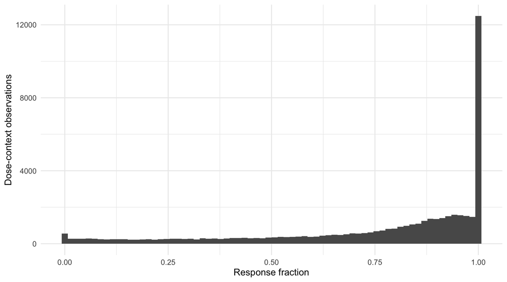

| fit_status | N |
| --- | --- |
| ok | 168110 |

| n_doses | N |
| --- | --- |
| 7 | 153019 |
| 5 | 15091 |

| fits | finite_IC50 | finite_AAC | finite_Rsquare | median_Rsquare | Rsquare_below_0_5 | AAC_outside_0_1 |
| --- | --- | --- | --- | --- | --- | --- |
| 168110 | 168110 | 168110 | 163775 | 0.8731653 | 41486 | 0 |

| four_parameter_dose_support | N |
| --- | --- |
| TRUE | 168110 |

## Molecular identifiers

Gene-level assays use the configured GENCODE release. Fusion pairs retain their component identifiers.

| assay | features | samples | duplicates | non_ensembl |
| --- | --- | --- | --- | --- |
| rnaseq.fpkm | 36998 | 752 | 0 | 0 |
| rnaseq.tpm | 36998 | 752 | 0 | 0 |
| rnaseq.read_count | 36998 | 752 | 0 | 0 |
| cnv.total_copy_number | 18281 | 747 | 0 | 0 |
| cnv.seg_mean | 18281 | 747 | 0 | 0 |
| cnv.gene_mean | 18281 | 747 | 0 | 0 |
| cnv.num_snps | 18281 | 747 | 0 | 0 |
| cnv.gatk_mean_log2_copy_ratio | 18281 | 747 | 0 | 0 |
| mutation.wes | 19986 | 750 | 0 | 0 |
| fusion.rnaseq | 4937 | 692 | 0 | 4937 |

| exclusion_reason | N | assay |
| --- | --- | --- |
| no_unique_current_Ensembl_match | 69 | cnv.gatk_mean_log2_copy_ratio_feature_mapping.tsv |
|  | 18281 | cnv.gatk_mean_log2_copy_ratio_feature_mapping.tsv |
| no_unique_current_Ensembl_match | 69 | cnv.gene_mean_feature_mapping.tsv |
|  | 18281 | cnv.gene_mean_feature_mapping.tsv |
| no_unique_current_Ensembl_match | 69 | cnv.num_snps_feature_mapping.tsv |
|  | 18281 | cnv.num_snps_feature_mapping.tsv |
| no_unique_current_Ensembl_match | 69 | cnv.seg_mean_feature_mapping.tsv |
|  | 18281 | cnv.seg_mean_feature_mapping.tsv |
| no_unique_current_Ensembl_match | 69 | cnv.total_copy_number_feature_mapping.tsv |
|  | 18281 | cnv.total_copy_number_feature_mapping.tsv |
| no_unique_current_Ensembl_match | 381 | mutation.wes_feature_mapping.tsv |
|  | 19986 | mutation.wes_feature_mapping.tsv |
| no_unique_current_Ensembl_match | 598 | rnaseq.fpkm_feature_mapping.tsv |
|  | 36998 | rnaseq.fpkm_feature_mapping.tsv |
| duplicate_gene_keep_lexical_first_feature | 3 | rnaseq.fpkm_feature_mapping.tsv |
| no_unique_current_Ensembl_match | 598 | rnaseq.read_count_feature_mapping.tsv |
|  | 36998 | rnaseq.read_count_feature_mapping.tsv |
| duplicate_gene_keep_lexical_first_feature | 3 | rnaseq.read_count_feature_mapping.tsv |
| no_unique_current_Ensembl_match | 598 | rnaseq.tpm_feature_mapping.tsv |
|  | 36998 | rnaseq.tpm_feature_mapping.tsv |
| duplicate_gene_keep_lexical_first_feature | 3 | rnaseq.tpm_feature_mapping.tsv |

## Response landscape and fit support

Physical wells, observed-reference synergy, fitted-reference synergy and curve summaries answer different questions. Positive HSA/Bliss excess means lower combination viability than the named reference. Missing fitted scores are not zero synergy. Loewe/ZIP fields explicitly retain their E0=1 assumption.

| metric | rows | finite | missing | median | p05 | p95 |
| --- | --- | --- | --- | --- | --- | --- |
| mean_HSA_observed_excess | 84055 | 84055 | 0 | -0.0006 | -0.0675 | 0.1037 |
| mean_Bliss_observed_excess | 84055 | 84055 | 0 | -0.0239 | -0.1077 | 0.0729 |
| mean_HSA_fitted_excess | 84055 | 84055 | 0 | 0.0002 | -0.0699 | 0.1031 |
| mean_Bliss_fitted_excess | 84055 | 84055 | 0 | -0.0278 | -0.1195 | 0.0684 |
| mean_Loewe_E0_1_excess | 84055 | 67213 | 16842 | 0.0192 | -0.0609 | 0.1334 |
| mean_ZIP_E0_1_excess | 84055 | 84055 | 0 | 0.0123 | -0.0752 | 0.1140 |

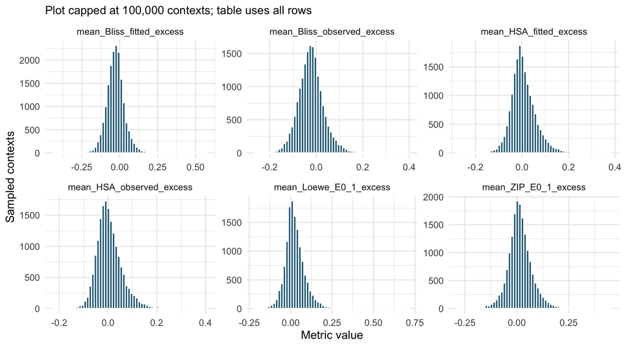

| n_dose1 | n_dose2 | n_dose_pairs | N |
| --- | --- | --- | --- |
| 7 | 7 | 49 | 70920 |
| 7 | 5 | 35 | 8476 |
| 5 | 7 | 35 | 2703 |
| 5 | 5 | 25 | 1956 |

| metric | rows | finite | missing | median | p05 | p95 |
| --- | --- | --- | --- | --- | --- | --- |
| AAC | 168110 | 168110 | 0 | 0.0980 | 0.0034 | 0.4559 |
| Rsquare | 168110 | 163775 | 4335 | 0.8732 | 0.1892 | 0.9999 |

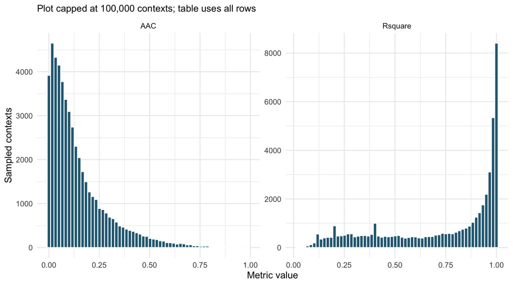

| n_doses | fit_status | contexts | finite_IC50 | finite_AAC | median_R2 | low_R2 |
| --- | --- | --- | --- | --- | --- | --- |
| 7 | ok | 153019 | 153019 | 153019 | 0.8488 | 40128 |
| 5 | ok | 15091 | 15091 | 15091 | 0.9801 | 1358 |

| comparison | contexts | paired | reference_only | recomputed_only | neither | Pearson | Spearman | mean_bias | median_bias | MAE | RMSE | p95_abs_error | descriptive_lower | descriptive_upper |
| --- | --- | --- | --- | --- | --- | --- | --- | --- | --- | --- | --- | --- | --- | --- |
| Observed-reference vs fitted-reference mean Bliss | 84055 | 84055 | 0 | 0 | 0 | 0.9642 | 0.9663 | -0.0054 | 0 | 0.0054 | 0.0163 | 0.0349 | -0.0355 | 0.0248 |

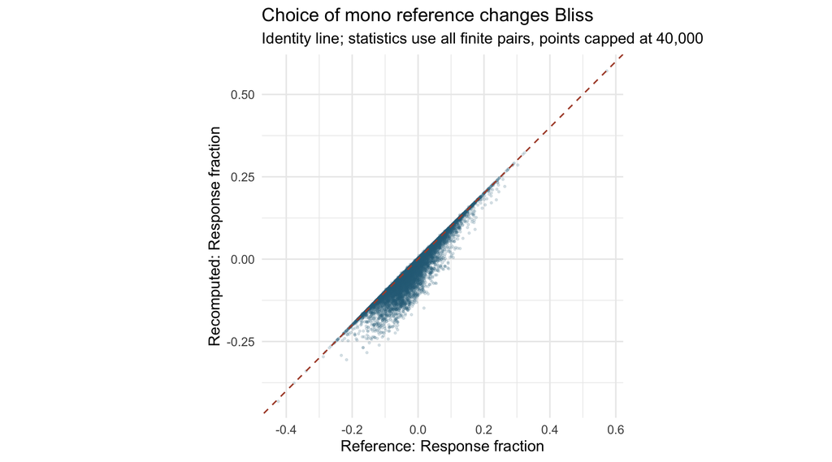

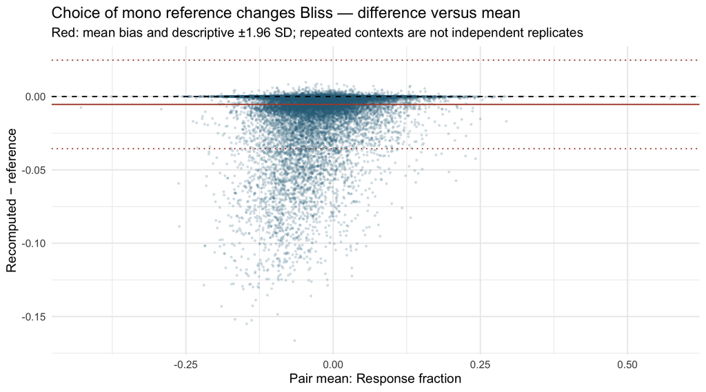

This comparison measures sensitivity to the choice of monotherapy reference. It is not independent biological validation. Limited dose support and flat responses can make fitted potency uncertain even when R² is high.

## Exploratory combination prioritization

Average technical contexts within each cell and ordered pair (and each anchor dose for Anchor), then weight cells equally. Display the ten highest observed-reference mean-Bliss pairs measured in at least ten cells. These are descriptive candidates, not validated combinations: dose design, tissue coverage and cell selection differ.

| treatment1id | treatment2id | cells | mean_Bliss | median_Bliss | SD_Bliss | fraction_positive | pair |
| --- | --- | --- | --- | --- | --- | --- | --- |
| AZD5991 | AZ-3202 | 375 | 0.1220 | 0.1110 | 0.0931 | 0.9253 | AZD5991 + AZ-3202 |
| AZD7648 | Etoposide | 376 | 0.0598 | 0.0592 | 0.0592 | 0.8537 | AZD7648 + Etoposide |
| AZD4320 | Paclitaxel | 375 | 0.0481 | 0.0417 | 0.0598 | 0.8160 | AZD4320 + Paclitaxel |
| SN-38 | Olaparib | 598 | 0.0448 | 0.0474 | 0.0434 | 0.8512 | SN-38 + Olaparib |
| Prexasertib | AZD1775 | 732 | 0.0435 | 0.0458 | 0.0588 | 0.7978 | Prexasertib + AZD1775 |
| Trametinib | Taselisib | 734 | 0.0390 | 0.0306 | 0.0704 | 0.7003 | Trametinib + Taselisib |
| SRA737 | AZD1775 | 376 | 0.0360 | 0.0341 | 0.0614 | 0.7181 | SRA737 + AZD1775 |
| AZD4320 | AZD1775 | 735 | 0.0336 | 0.0307 | 0.0458 | 0.7633 | AZD4320 + AZD1775 |
| Doxorubicin | AZD7648 | 732 | 0.0335 | 0.0324 | 0.0510 | 0.7295 | Doxorubicin + AZD7648 |
| AZD6738 | Gemcitabine | 375 | 0.0263 | 0.0211 | 0.0516 | 0.7040 | AZD6738 + Gemcitabine |

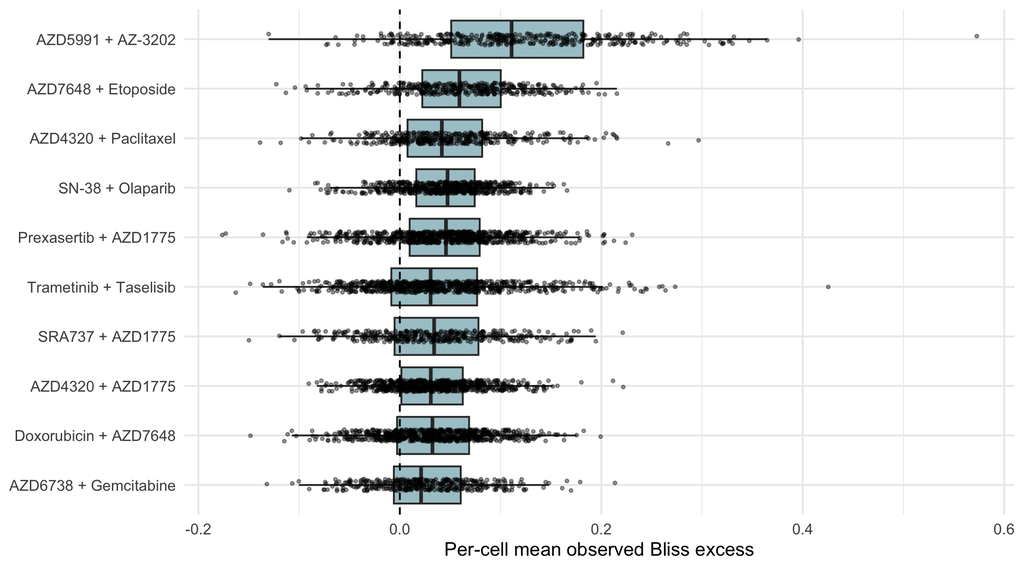

## Molecular coverage and sample distributions

The GDSC CMP 2022 RNA-seq release contains Sanger and Broad samples with recorded per-sample provenance. FPKM, TPM and read counts remain separate assays on their original stored scales. The plots describe coverage and distributions; they do not establish equivalence to historical expression releases.

| assay | features | samples | missing_screen_samples |
| --- | --- | --- | --- |
| rnaseq.fpkm | 36998 | 752 | 3 |
| rnaseq.tpm | 36998 | 752 | 3 |
| rnaseq.read_count | 36998 | 752 | 3 |
| cnv.total_copy_number | 18281 | 747 | 8 |
| cnv.seg_mean | 18281 | 747 | 8 |
| cnv.gene_mean | 18281 | 747 | 8 |
| cnv.num_snps | 18281 | 747 | 8 |
| cnv.gatk_mean_log2_copy_ratio | 18281 | 747 | 8 |
| mutation.wes | 19986 | 750 | 5 |
| fusion.rnaseq | 4937 | 692 | 63 |

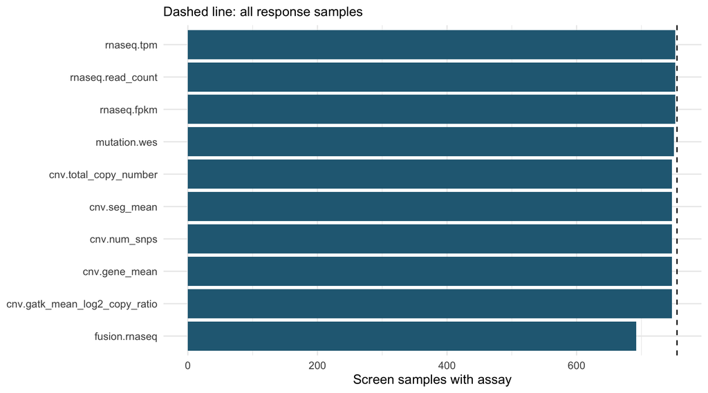

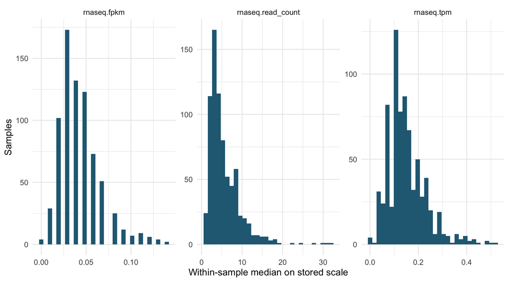

## Published versus recomputed Matrix synergy

Public well-statistics retain fitted mono references and published HSA/Bliss excess. Both use viability fractions and positive synergy as expected minus observed combination viability. Comparisons use the same sample, plate, matrix, ordered drug pair and dose context in the saved synergy assay. Repeated physical wells are averaged within that exact context. First reconstruct the published scores from their own fitted references to distinguish import errors from model changes.

| metric | contexts | missing_pattern_identical | maximum_absolute_error |
| --- | --- | --- | --- |
| HSA | 3915245 | TRUE | 0 |
| Bliss | 3915245 | TRUE | 0 |

| comparison | contexts | paired | reference_only | recomputed_only | neither | Pearson | Spearman | mean_bias | median_bias | MAE | RMSE | p95_abs_error | descriptive_lower | descriptive_upper |
| --- | --- | --- | --- | --- | --- | --- | --- | --- | --- | --- | --- | --- | --- | --- |
| Published vs recomputed HSA | 3915245 | 3915245 | 0 | 0 | 0 | 0.7758 | 0.7003 | -0.0154 | -0.0127 | 0.0618 | 0.0828 | 0.1730 | -0.1749 | 0.1442 |
| Published vs recomputed Bliss | 3915245 | 3915245 | 0 | 0 | 0 | 0.7071 | 0.6267 | -0.0210 | -0.0168 | 0.0699 | 0.0917 | 0.1872 | -0.1960 | 0.1540 |

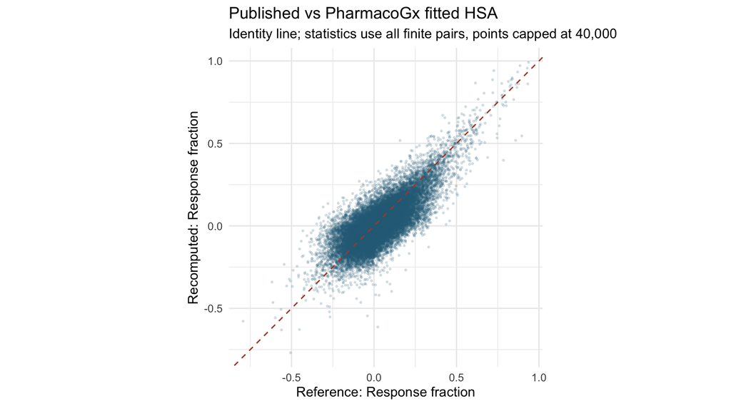

| sampleid | treatment1id | treatment2id | plateid | matrixid | treatment1dose | treatment2dose | viability | viability_1 | viability_2 | viability_1_fitted_published | viability_2_fitted_published | published | recomputed | difference |
| --- | --- | --- | --- | --- | --- | --- | --- | --- | --- | --- | --- | --- | --- | --- |
| 1949 | AZD6738 | Olaparib | 40441 | 1 | 0.010 | 0.0100 | 0.6741 | 0.0389 | 0.8402 | 0.9987 | 0.9995 | 0.3246 | -0.5962 | -0.9208 |
| 1949 | AZD6738 | Olaparib | 40441 | 1 | 0.010 | 0.0316 | 0.9044 | 0.0389 | 0.9988 | 0.9987 | 0.9986 | 0.0942 | -0.8265 | -0.9207 |
| 1949 | AZD6738 | Olaparib | 40441 | 1 | 0.010 | 0.1000 | 0.0625 | 0.0389 | 0.8440 | 0.9987 | 0.9965 | 0.9341 | 0.0154 | -0.9187 |
| 1949 | AZD6738 | Olaparib | 40441 | 1 | 0.010 | 0.3163 | 0.6666 | 0.0389 | 0.8025 | 0.9987 | 0.9913 | 0.3247 | -0.5887 | -0.9134 |
| 1949 | AZD6738 | Olaparib | 40441 | 1 | 0.010 | 1.0002 | 0.9799 | 0.0389 | 1.0000 | 0.9987 | 0.9781 | -0.0018 | -0.9020 | -0.9002 |
| 1167 | AZD0156 | AZD2811 | 41835 | 10 | 0.001 | 0.0010 | 1.0000 | 0.0914 | 1.0000 | 0.9999 | 0.9955 | -0.0045 | -0.8992 | -0.8947 |

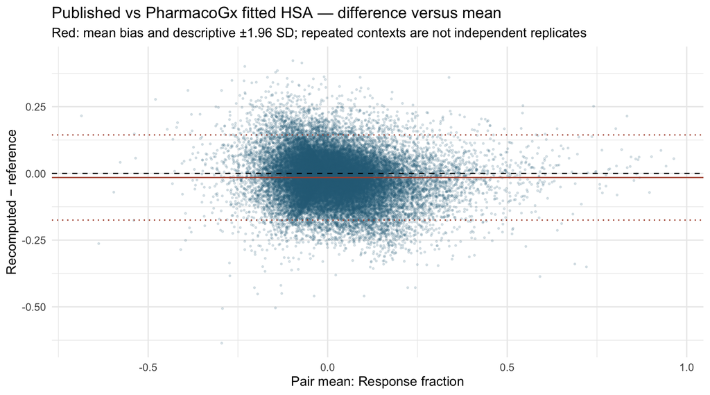

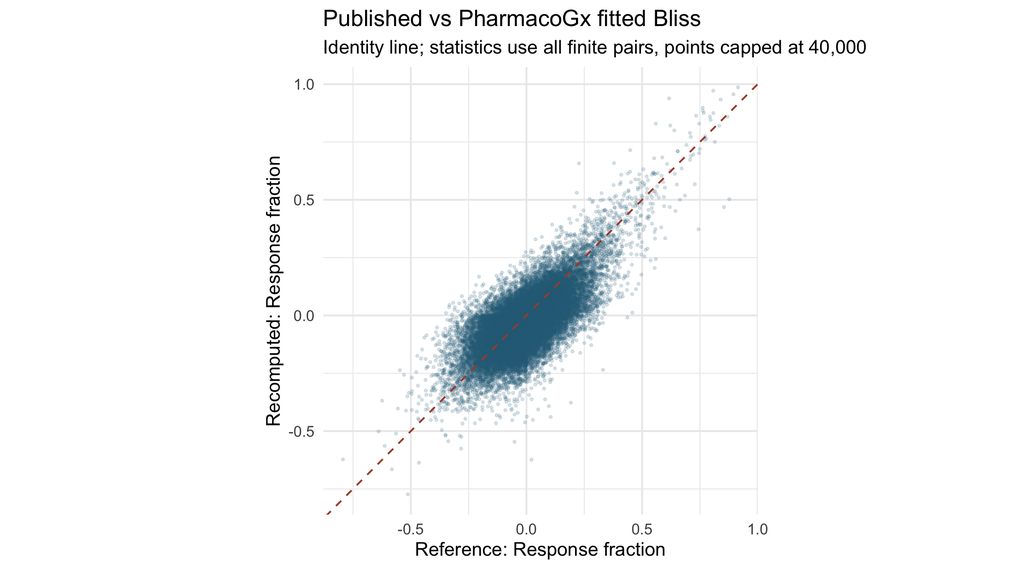

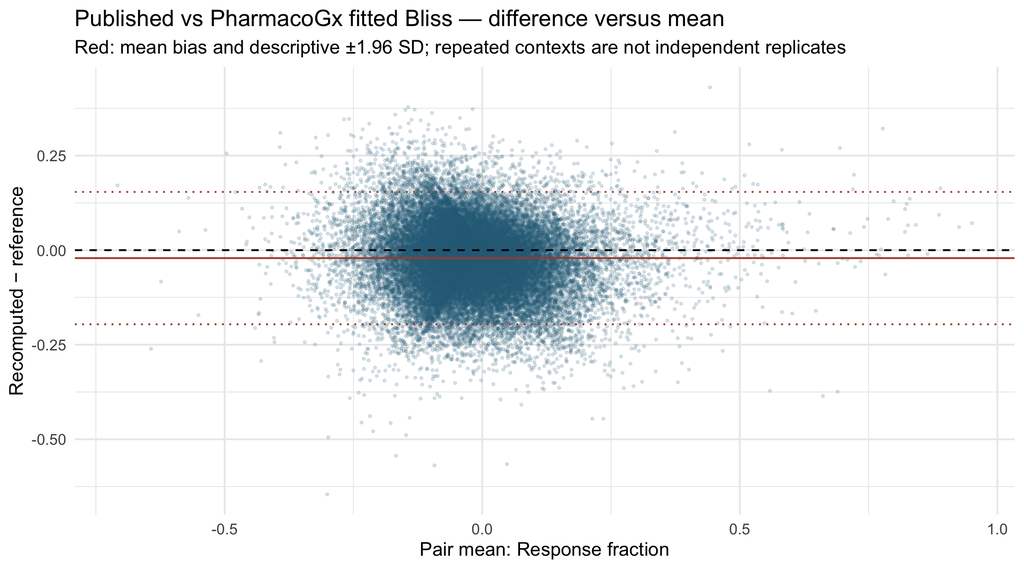

| sampleid | treatment1id | treatment2id | plateid | matrixid | treatment1dose | treatment2dose | viability | viability_1 | viability_2 | viability_1_fitted_published | viability_2_fitted_published | published | recomputed | difference |
| --- | --- | --- | --- | --- | --- | --- | --- | --- | --- | --- | --- | --- | --- | --- |
| 1949 | AZD6738 | Olaparib | 40441 | 1 | 0.010 | 0.0100 | 0.6741 | 0.0389 | 0.8402 | 0.9987 | 0.9995 | 0.3240 | -0.6062 | -0.9302 |
| 1949 | AZD6738 | Olaparib | 40441 | 1 | 0.010 | 0.0316 | 0.9044 | 0.0389 | 0.9988 | 0.9987 | 0.9986 | 0.0929 | -0.8365 | -0.9294 |
| 1949 | AZD6738 | Olaparib | 40441 | 1 | 0.010 | 0.1000 | 0.0625 | 0.0389 | 0.8440 | 0.9987 | 0.9965 | 0.9327 | 0.0055 | -0.9273 |
| 1949 | AZD6738 | Olaparib | 40441 | 1 | 0.010 | 0.3163 | 0.6666 | 0.0389 | 0.8025 | 0.9987 | 0.9913 | 0.3234 | -0.5983 | -0.9216 |
| 1949 | AZD6738 | Olaparib | 40441 | 1 | 0.010 | 1.0002 | 0.9799 | 0.0389 | 1.0000 | 0.9987 | 0.9781 | -0.0031 | -0.9059 | -0.9028 |
| 1167 | AZD0156 | AZD2811 | 41835 | 10 | 0.001 | 0.0010 | 1.0000 | 0.0914 | 1.0000 | 0.9999 | 0.9955 | -0.0047 | -0.8992 | -0.8945 |

| comparison | contexts | paired | reference_only | recomputed_only | neither | Pearson | Spearman | mean_bias | median_bias | MAE | RMSE | p95_abs_error | descriptive_lower | descriptive_upper |
| --- | --- | --- | --- | --- | --- | --- | --- | --- | --- | --- | --- | --- | --- | --- |
| Same-context matrix mean HSA | 84055 | 84055 | 0 | 0 | 0 | 0.8819 | 0.8447 | -0.0153 | -0.0125 | 0.022 | 0.0303 | 0.0628 | -0.0666 | 0.0360 |
| Same-context matrix mean Bliss | 84055 | 84055 | 0 | 0 | 0 | 0.7606 | 0.7014 | -0.0207 | -0.0149 | 0.032 | 0.0435 | 0.0924 | -0.0958 | 0.0544 |

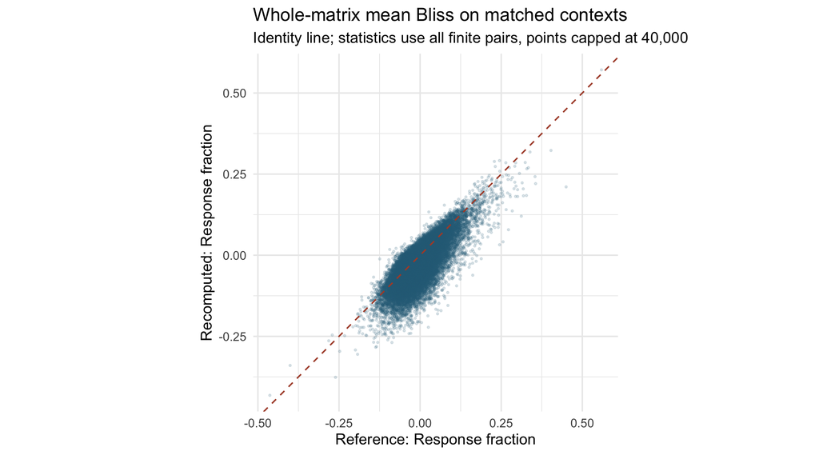

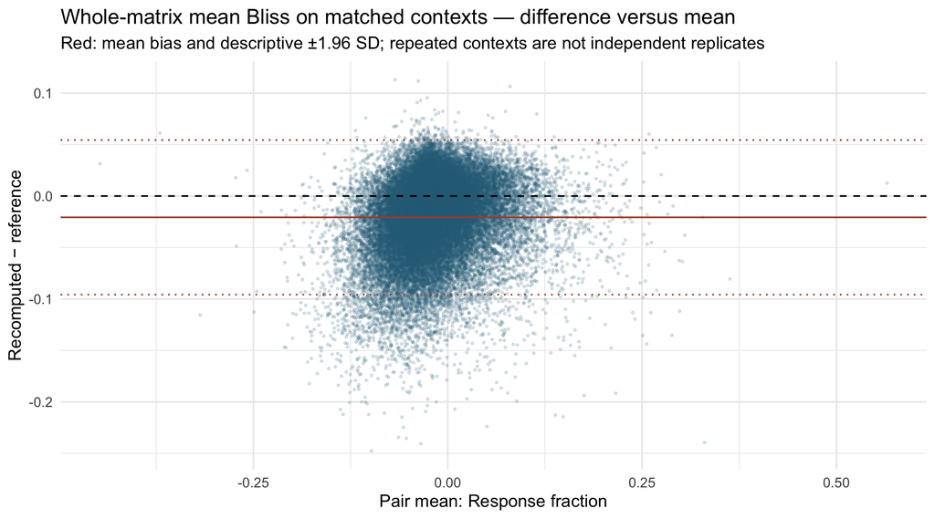

Whole-matrix source means here are **derived from published well scores**, not asserted to equal portal best-window or single-orientation summaries. Source IC50/AUC metrics need their own model, unit and dose-range reconciliation before comparison. Correlation measures association, not agreement: inspect bias and outliers alongside it.

## Representative measured response surfaces

Select contexts nearest the 10th, 50th and 90th percentiles of mean observed Bliss, plus the largest observed-versus-fitted mean-Bliss discrepancy. These are deterministic diagnostic examples, not selected successes. Drug orientation and technical context are preserved. For Anchor, the measured seven-dose library curve and stored four-parameter fit are shown at a fixed anchor dose; for matrices, tile colors show measured viability and observed Bliss on the actual dose grid.

| sampleid | tech_rep | plateid | matrixid | treatment1id | treatment2id | example | mean_Bliss_observed_excess | mean_Bliss_fitted_excess |
| --- | --- | --- | --- | --- | --- | --- | --- | --- |
| 937 | 3_GDSC_008_44428 | 44428 | 7 | Venetoclax | AZD7648 | 1: HCC70 \| Venetoclax + AZD7648 | -0.0878 | -0.0878 |
| 752 | 2_GDSC_007_39513 | 39513 | 9 | AZD0156 | AZD6738 | 2: OACM5-1 \| AZD0156 + AZD6738 | -0.0239 | -0.0241 |
| 1641 | 4_GDSC_009_57006 | 57006 | 7 | Capivasertib | Palbociclib | 3: SK-LMS-1 \| Capivasertib + Palbociclib | 0.0462 | 0.0462 |
| 997 | 5_GDSC_010_54970 | 54970 | 9 | Lapatinib | Selumetinib | 4: T84 \| Lapatinib + Selumetinib | 0.0179 | -0.1485 |

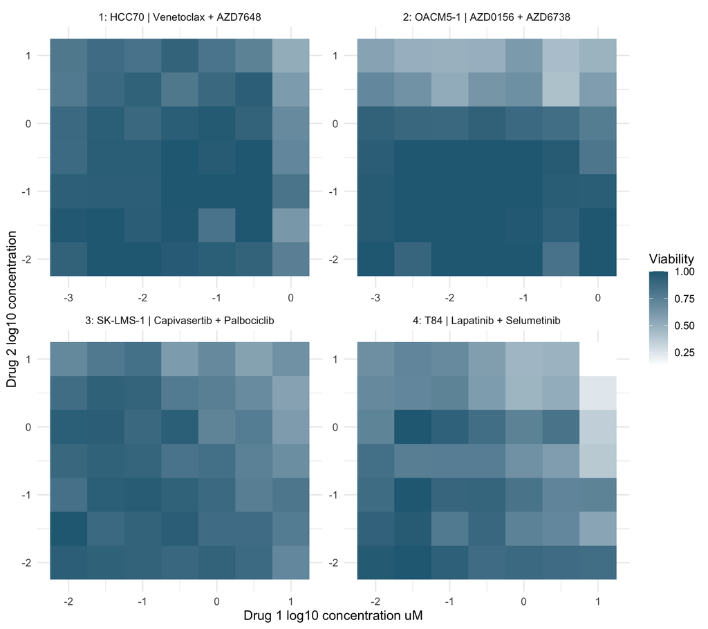

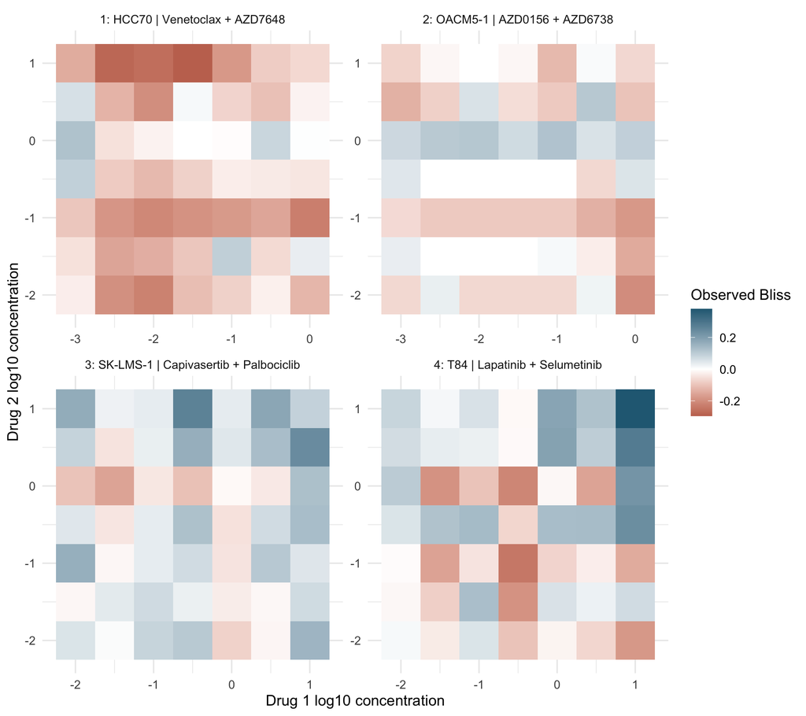

## Reported fit quality and the stored curve

For these fitted profiles, `Rsquare` is calculated before the returned asymptotes are truncated to [0,1]. It uses `1 - var(residual)/var(response)`, which also removes a constant residual bias. Consequently, optimizer-reported R² need not describe the returned curve used for downstream metrics. Existing stored fit parameters and reported R² are preserved.

The diagnostics evaluate the stored curve at its modeling concentrations and report both the variance-based statistic and the bias-sensitive `1 - SSE/SST`. Constant-response curves have undefined R². Negative values indicate poor fit and are retained. These are in-sample diagnostics, not tests of predictive performance or potency identifiability.

| assay | fit_status | asymptote_at_boundary | contexts | finite_reported | finite_returned | reported_returned_differ | max_absolute_difference | median_reported | median_returned_variance | reported_below_0_5 | returned_variance_below_0_5 | returned_SSE_below_0_5 |
| --- | --- | --- | --- | --- | --- | --- | --- | --- | --- | --- | --- | --- |
| monotherapy | ok | FALSE | 83784 | 83784 | 83784 | 0 | 0.0000 | 0.8913 | 0.8913 | 18631 | 18631 | 18631 |
| monotherapy | ok | TRUE | 84326 | 79991 | 79991 | 50171 | 0.5023 | 0.8444 | 0.8321 | 22855 | 23752 | 25999 |

| sampleid | tech_rep | plateid | treatment1id | matrixid | Hill_slope | E0 | E_inf | EC50 | reported_Rsquare | stored_n_doses | fit_status | model_points | input_n_doses | finite_predictions | response_variance | residual_variance | SSE | mean_bias_observed_minus_prediction | returned_variance_Rsquare | returned_SSE_Rsquare | assay | asymptote_at_boundary | difference_reported_minus_returned |
| --- | --- | --- | --- | --- | --- | --- | --- | --- | --- | --- | --- | --- | --- | --- | --- | --- | --- | --- | --- | --- | --- | --- | --- |
| 1145 | 1_Sandpiper-01_24085 | 24085 | Olaparib | 2 | 4.5000 | 0.9561 | 1.0000 | 4.2027 | 0.7471 | 5 | ok | 5 | 5 | 5 | 0.0005 | 4e-04 | 0.0018 | 0.0072 | 0.2448 | 0.1171 | monotherapy | TRUE | 0.5023 |
| 700 | 3_GDSC_008_50837 | 50837 | AZD7648 | 7 | 1.9178 | 1.0000 | 0.9289 | 0.0058 | 0.9163 | 7 | ok | 7 | 7 | 7 | 0.0008 | 4e-04 | 0.0032 | 0.0087 | 0.4173 | 0.3014 | monotherapy | TRUE | 0.4989 |
| 2195 | 2_GDSC_007_41737 | 41737 | AZD1775 | 6 | 2.0215 | 1.0000 | 0.9651 | 0.0042 | 0.6831 | 5 | ok | 5 | 5 | 5 | 0.0003 | 3e-04 | 0.0013 | 0.0067 | 0.1878 | 0.0229 | monotherapy | TRUE | 0.4954 |
| 372 | 1_Sandpiper-01_23137 | 23137 | AZD0156 | 2 | 4.5000 | 1.0000 | 0.9522 | 0.0218 | 0.7592 | 5 | ok | 5 | 5 | 5 | 0.0006 | 4e-04 | 0.0021 | 0.0077 | 0.2644 | 0.1386 | monotherapy | TRUE | 0.4949 |
| 1145 | 2_GDSC_007_42001 | 42001 | Olaparib | 2 | 4.5000 | 0.9414 | 1.0000 | 14.2868 | 0.8209 | 7 | ok | 7 | 7 | 7 | 0.0003 | 2e-04 | 0.0015 | 0.0048 | 0.3299 | 0.2468 | monotherapy | TRUE | 0.4910 |
| 1372 | 4_GDSC_009_56751 | 56751 | Selumetinib | 8 | 4.5000 | 0.9265 | 1.0000 | 12.4983 | 0.9021 | 7 | ok | 7 | 7 | 7 | 0.0009 | 5e-04 | 0.0034 | 0.0077 | 0.4195 | 0.3377 | monotherapy | TRUE | 0.4825 |
| 1501 | 1_Sandpiper-01_28857 | 28857 | Olaparib | 2 | 4.5000 | 0.9380 | 1.0000 | 3.8940 | 0.8110 | 5 | ok | 5 | 5 | 5 | 0.0009 | 6e-04 | 0.0029 | 0.0095 | 0.3383 | 0.2181 | monotherapy | TRUE | 0.4726 |
| 711 | 1_Sandpiper-01_22051 | 22051 | Olaparib | 2 | 1.0161 | 1.0000 | 0.9072 | 0.0074 | 0.9940 | 5 | ok | 5 | 5 | 5 | 0.0006 | 3e-04 | 0.0018 | 0.0119 | 0.5298 | 0.2128 | monotherapy | TRUE | 0.4642 |
| 346 | 3_GDSC_008_51578 | 51578 | Venetoclax | 8 | 0.6052 | 1.0000 | 0.9219 | 0.0002 | 0.8773 | 7 | ok | 7 | 7 | 7 | 0.0009 | 5e-04 | 0.0051 | 0.0174 | 0.4233 | 0.0191 | monotherapy | TRUE | 0.4541 |
| 1792 | 5_GDSC_010_54519 | 54519 | AZD1775 | 7 | 1.4996 | 1.0000 | 0.9143 | 0.0054 | 0.9228 | 5 | ok | 5 | 5 | 5 | 0.0013 | 7e-04 | 0.0038 | 0.0146 | 0.4702 | 0.2648 | monotherapy | TRUE | 0.4526 |

All other tables and plots labeled `Rsquare` or R² retain the original optimizer-reported statistic unless explicitly labeled as returned-curve diagnostics. The full diagnostic table preserves identifiers, assay, dose counts and both quality definitions for review.